# Chapter 2: simple regression

We start again by loading the data.

```r
# Load the datasets from the RData file
load("../dataCreated/listings_clean.RData")

# Display the first few rows of the cleaned dataset
head(listings_clean)
```

|  | neighbourhood_cleansed | id | listing_url | scrape_id | last_scraped | source | name | description | neighborhood_overview | picture_url | host_id | host_url | host_name | host_since | host_location | host_about | host_response_time | host_response_rate | host_acceptance_rate | host_is_superhost | host_thumbnail_url | host_picture_url | host_neighbourhood | host_listings_count | host_total_listings_count | host_verifications | host_has_profile_pic | host_identity_verified | neighbourhood | … |
| --- | --- | --- | --- | --- | --- | --- | --- | --- | --- | --- | --- | --- | --- | --- | --- | --- | --- | --- | --- | --- | --- | --- | --- | --- | --- | --- | --- | --- | --- | --- |
| 1 | 's-Gravenland | 1.012115e+18 | https://www.airbnb.com/rooms/1012114818168132512 | 2.024063e+13 | 2024-06-25 | city scrape | High-end Serviced Apartment with two bedrooms | Nestled in Rotterdam's prestigious neighborhood ‘Kralingen’, our brand new residential apartment complex awaits, offering your temporary home away from home. Each of these exquisite apartments is thou… | In Kralingen, a charming district within a stone's throw of the Rotterdam city center, convenience becomes your constant companion with supermarkets, boutiques, culinary havens, and effortless access … | https://a0.muscache.com/pictures/miso/Hosting-1012114818168132512/original/12df4128-3a61-42a2-a47a-b61865cc1dde.jpeg | 543381697 | https://www.airbnb.com/users/show/543381697 | BirdsEye Short Stay | 2023-10-25 | NA | NA | within an hour | 96% | 82% | TRUE | https://a0.muscache.com/im/pictures/user/User-543381697/original/48eae732-3db4-4508-9f9c-ca2a133bd4b1.png?aki_policy=profile_small | https://a0.muscache.com/im/pictures/user/User-543381697/original/48eae732-3db4-4508-9f9c-ca2a133bd4b1.png?aki_policy=profile_x_medium | NA | 2 | 2 | ['email', 'phone'] | TRUE | TRUE | Rotterdam, Zuid-Holland, Netherlands | … |
| 2 | 's-Gravenland | 1.032655e+18 | https://www.airbnb.com/rooms/1032655139418809797 | 2.024063e+13 | 2024-06-25 | city scrape | High-end Serviced Apartment with one bedroom | Nestled in Rotterdam's prestigious neighborhood ‘Kralingen’, our brand new residential apartment complex awaits, offering your temporary home away from home. Each of these exquisite apartments is thou… | In Kralingen, a charming district within a stone's throw of the Rotterdam city center, convenience becomes your constant companion with supermarkets, boutiques, culinary havens, and effortless access … | https://a0.muscache.com/pictures/miso/Hosting-1032655139418809797/original/69761ba0-3d06-4760-a1e3-010b990fcd79.jpeg | 543381697 | https://www.airbnb.com/users/show/543381697 | BirdsEye Short Stay | 2023-10-25 | NA | NA | within an hour | 96% | 82% | TRUE | https://a0.muscache.com/im/pictures/user/User-543381697/original/48eae732-3db4-4508-9f9c-ca2a133bd4b1.png?aki_policy=profile_small | https://a0.muscache.com/im/pictures/user/User-543381697/original/48eae732-3db4-4508-9f9c-ca2a133bd4b1.png?aki_policy=profile_x_medium | NA | 2 | 2 | ['email', 'phone'] | TRUE | TRUE | Rotterdam, Zuid-Holland, Netherlands | … |
| 3 | Agniesebuurt | 8.217094e+17 | https://www.airbnb.com/rooms/821709375116932602 | 2.024063e+13 | 2024-06-26 | city scrape | King Room | Our King Room is ideal for couples! Enjoy sleeping in our superior king double bed and wake up rested for all the activities you have planned for the next day. Of course your room is equipped with a p… | NA | https://a0.muscache.com/pictures/miso/Hosting-821709375116932602/original/3e333f5e-b739-4f17-873f-1628a963e0b2.jpeg | 365217950 | https://www.airbnb.com/users/show/365217950 | Bianca | 2020-08-31 | NA | NA | within an hour | 85% | 99% | FALSE | https://a0.muscache.com/im/pictures/user/cc6977b4-d482-4111-9460-af2fb8e59781.jpg?aki_policy=profile_small | https://a0.muscache.com/im/pictures/user/cc6977b4-d482-4111-9460-af2fb8e59781.jpg?aki_policy=profile_x_medium | NA | 13 | 13 | ['phone'] | TRUE | TRUE | NA | … |
| 4 | Agniesebuurt | 9.846371e+17 | https://www.airbnb.com/rooms/984637143310796841 | 2.024063e+13 | 2024-06-25 | city scrape | Charming Urban Retreat - with parking | Indulge in the allure of our charming centrally located urban retreat. Enjoy the sunlight on the balcony and make use of our spacious well-equiped kitchen with dining table. After a long day of explor… | NA | https://a0.muscache.com/pictures/miso/Hosting-984637143310796841/original/b16e8b3a-e987-4119-b146-73e81695184a.jpeg | 116041691 | https://www.airbnb.com/users/show/116041691 | Bastiaan | 2017-02-12 | Rotterdam, Netherlands | NA | within an hour | 100% | 94% | TRUE | https://a0.muscache.com/im/pictures/user/db5760d4-54b8-467b-949a-45f95150a62d.jpg?aki_policy=profile_small | https://a0.muscache.com/im/pictures/user/db5760d4-54b8-467b-949a-45f95150a62d.jpg?aki_policy=profile_x_medium | NA | 1 | 1 | ['email', 'phone', 'work_email'] | TRUE | TRUE | NA | … |
| 5 | Agniesebuurt | 7.665157e+17 | https://www.airbnb.com/rooms/766515651027141909 | 2.024063e+13 | 2024-06-25 | city scrape | Bed in Mixed Dormitory Room | Sleeping in a dorm room is not only very cozy, it’s also super cheap! Our Bed in Mixed Dormitory Room is a mixed (m/f) dorm with a super comfortable bunk bed. Who you share your room with is still a s… | Within walking distance to Rotterdam Centraal Station and just a short drive from Rotterdam The Hague Airport (RTM) you are located in the vibrant area of Rotterdam North.Set along the banks of the Ni… | https://a0.muscache.com/pictures/miso/Hosting-766515651027141909/original/7b624fb0-bb29-4055-a801-3ec8e28c4567.jpeg | 365217950 | https://www.airbnb.com/users/show/365217950 | Bianca | 2020-08-31 | NA | NA | within an hour | 85% | 99% | FALSE | https://a0.muscache.com/im/pictures/user/cc6977b4-d482-4111-9460-af2fb8e59781.jpg?aki_policy=profile_small | https://a0.muscache.com/im/pictures/user/cc6977b4-d482-4111-9460-af2fb8e59781.jpg?aki_policy=profile_x_medium | NA | 13 | 13 | ['phone'] | TRUE | TRUE | Rotterdam, Zuid-Holland, Netherlands | … |
| 6 | Agniesebuurt | 6.455105e+17 | https://www.airbnb.com/rooms/645510482091510278 | 2.024063e+13 | 2024-06-25 | city scrape | Studio floor with own kitchen & toilet - central | 10MIN WALK FROM CENTRAL.We have 2 floor apartment and we are renting out our upstairs which is a complete studio. Our flat is located 10 min walk away from Rotterdam central station in front of a peac… | Super close to central station 10 min walk away. The location called Oude Noord 'Het Oude Noorden' is the most rising neighbourhood of Rotterdam with many hip cafe & restaurants. You can find super ni… | https://a0.muscache.com/pictures/b3738de7-f406-438a-ab22-29164d7898d8.jpg | 16080777 | https://www.airbnb.com/users/show/16080777 | Sevim | 2014-05-28 | Rotterdam, Netherlands | We are a young couple living in Rotterdam both working in corporate. I am Turkish and my boyfriend is Dutch, we are hospitable & clean couple. We love sharing our place & meeting with new people. We a… | within a few hours | 100% | 21% | FALSE | https://a0.muscache.com/im/pictures/user/0d800f6b-1061-4a87-b4d3-cd0d70671a4a.jpg?aki_policy=profile_small | https://a0.muscache.com/im/pictures/user/0d800f6b-1061-4a87-b4d3-cd0d70671a4a.jpg?aki_policy=profile_x_medium | NA | 2 | 2 | ['email', 'phone', 'work_email'] | TRUE | TRUE | Rotterdam, Zuid-Holland, Netherlands | … |

Filter the data so that we use only listings for at most 6 people. From now on use this

```r
listings_clean_filtered <- listings_clean %>%
  filter(accommodates <= 6)
```

Regress price on `review_scores_rating`.

```r
# Run a linear regression of price on review_scores_rating
model <- lm(price ~ review_scores_rating, data = listings_clean_filtered)

# Display the summary of the regression model
summary(model)
```

```
##
## Call:
## lm(formula = price ~ review_scores_rating, data = listings_clean_filtered)
##
## Residuals:
##      Min       1Q   Median       3Q      Max
## -104.965  -43.824   -7.964   32.321  163.448
##
## Coefficients:
##                      Estimate Std. Error t value Pr(>|t|)
## (Intercept)             63.92      63.57   1.005    0.315
## review_scores_rating    14.27      13.37   1.067    0.287
##
## Residual standard error: 58.09 on 419 degrees of freedom
## Multiple R-squared:  0.00271,    Adjusted R-squared:  0.0003294
## F-statistic: 1.138 on 1 and 419 DF,  p-value: 0.2866
```

Run a regression of price on how many people can be accommodated.

```r
# Run a linear regression of price on accommodates
model_accommodates <- lm(price ~ accommodates, data = listings_clean_filtered)

# Display the summary of the regression model
summary(model_accommodates)
```

```
##
## Call:
## lm(formula = price ~ accommodates, data = listings_clean_filtered)
##
## Residuals:
##     Min      1Q  Median      3Q     Max
## -144.65  -33.46  -10.91   22.35  159.90
##
## Coefficients:
##              Estimate Std. Error t value Pr(>|t|)
## (Intercept)    60.731      5.735   10.59   <2e-16 ***
## accommodates   25.183      1.855   13.57   <2e-16 ***
## ---
## Signif. codes:  0 '***' 0.001 '**' 0.01 '*' 0.05 '.' 0.1 ' ' 1
##
## Residual standard error: 48.48 on 419 degrees of freedom
## Multiple R-squared:  0.3055, Adjusted R-squared:  0.3038
## F-statistic: 184.3 on 1 and 419 DF,  p-value: < 2.2e-16
```

On slide 21, we have said that the sample moment conditions immediately imply that: 1. the average residual is zero 2. the average covariance between the residual and the regressor is zero 3. the regression line goes through the average of the dependent variable and the regressor.

We now verify this.

```r
# 1. Verify that the average residual is zero
residuals_accommodates <- residuals(model_accommodates)
mean_residuals <- round(mean(residuals_accommodates),5)
cat("1. Average of residuals:", mean_residuals, "\n")
```

```
## 1. Average of residuals: 0
```

```r
# 2. Verify that the average covariance between the residual and the regressor (accommodates) is zero
cov_residuals_regressor <- round(cov(residuals_accommodates, listings_clean_filtered$accommodates),5)
cat("2. Covariance between residuals and accommodates:", cov_residuals_regressor, "\n")
```

```
## 2. Covariance between residuals and accommodates: 0
```

```r
# 3. Verify that the regression line goes through the averages of the dependent variable and the regressor
mean_price <- mean(listings_clean_filtered$price)
mean_accommodates <- mean(listings_clean_filtered$accommodates)

# Calculate the predicted price at the average of accommodates
predicted_price_at_mean <- coef(model_accommodates)[1] + coef(model_accommodates)[2] * mean_accommodates

cat("3. Average price:", mean_price, "\n")
```

```
## 3. Average price: 131.6746
```

```r
cat("   Predicted price at average accommodates:", predicted_price_at_mean, "\n")
```

```
##    Predicted price at average accommodates: 131.6746
```

We have also said that the total sum of squares for the dependent variable is equal to the explained sum of squares plus the residual sum of squares. We can also verify this.

```r
# 1. Calculate the Total Sum of Squares (TSS)
mean_price <- mean(listings_clean_filtered$price)
TSS <- sum((listings_clean_filtered$price - mean_price)^2)
cat("Total Sum of Squares (TSS):", TSS, "\n")
```

```
## Total Sum of Squares (TSS): 1417766
```

```r
# 2. Calculate the Residual Sum of Squares (RSS)
RSS <- sum(residuals_accommodates^2)
cat("Residual Sum of Squares (RSS):", RSS, "\n")
```

```
## Residual Sum of Squares (RSS): 984669.4
```

```r
# 3. Calculate the Explained Sum of Squares (ESS)
# ESS is the difference between TSS and RSS
ESS <- TSS - RSS
cat("Explained Sum of Squares (ESS):", ESS, "\n")
```

```
## Explained Sum of Squares (ESS): 433097
```

```r
# 4. Verify that TSS = ESS + RSS
cat("TSS == ESS + RSS:", TSS == (ESS + RSS), "\n")
```

```
## TSS == ESS + RSS: TRUE
```

From this we can also compute the $R^2$ measure by hand.

```r
# 1. Calculate Total Sum of Squares (TSS)
mean_price <- mean(listings_clean_filtered$price)
TSS <- sum((listings_clean_filtered$price - mean_price)^2)

# 2. Calculate Residual Sum of Squares (RSS)
RSS <- sum(residuals_accommodates^2)

# 3. Calculate Explained Sum of Squares (ESS)
ESS <- TSS - RSS

# 4. Calculate R^2 using the formula R^2 = ESS / TSS or 1 - RSS / TSS
R_squared <- 1 - (RSS / TSS)

# Display the result
cat("R^2 (by hand):", round(R_squared,4), "\n")
```

```
## R^2 (by hand): 0.3055
```

It is the same as above in the regressian output (which of course has to be the case)!

Next we use the Stargazer package that we loaded in the beginning to produce a nice table with regression results for three different specifications. See slide 24 for details.

```r
# 1. Run a level-level regression of price on accommodates
level_level <- lm(price ~ accommodates, data = listings_clean_filtered)

# 2. Run a log-level regression of log(price) on accommodates
log_level <- lm(log(price) ~ accommodates, data = listings_clean_filtered)

# 3. Run a log-log regression of log(price) on log(accommodates)
log_log <- lm(log(price) ~ log(accommodates), data = listings_clean_filtered)

# 4. Create a table with stargazer displaying all three results
stargazer(level_level, log_level, log_log,
          type = "text",
          title = "Regression Results",
          column.labels = c("level-level", "log-level", "log-log"),
          dep.var.labels = "price",
          covariate.labels = c("accommodates", "log(accommodates)", "constant"),
          omit.stat = c("f", "ser"),
          digits = 3)
```

```
##
## Regression Results
## ================================================
##                        Dependent variable:
##                   ------------------------------
##                      price        log(price)
##                   level-level log-level log-log
##                       (1)        (2)      (3)
## ------------------------------------------------
## accommodates       25.183***  0.210***
##                     (1.855)    (0.015)
##
## log(accommodates)                       0.639***
##                                         (0.040)
##
## constant           60.731***  4.186***  4.180***
##                     (5.735)    (0.046)  (0.041)
##
## ------------------------------------------------
## Observations          421        421      421
## R2                   0.305      0.322    0.381
## Adjusted R2          0.304      0.320    0.379
## ================================================
## Note:                *p<0.1; **p<0.05; ***p<0.01
```

Finally, we produce a figure with the data points and the three fitted regression lines.[^1]

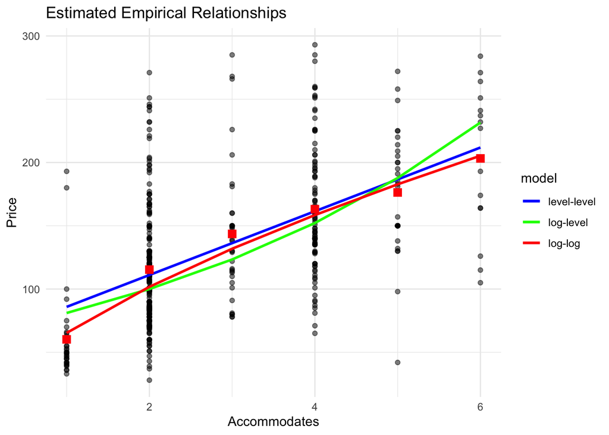

```r
# 1. Create a new data frame with predictions
listings_clean_filtered$pred_level_level <- predict(level_level, newdata = listings_clean_filtered)
listings_clean_filtered$pred_log_level <- exp(predict(log_level, newdata = listings_clean_filtered))
listings_clean_filtered$pred_log_log <- exp(predict(log_log, newdata = listings_clean_filtered))

# 2. Calculate the average price for each value of accommodates
avg_prices <- listings_clean_filtered %>%
  group_by(accommodates) %>%
  summarise(avg_price = mean(price))

# 3. Scatter plot of the actual data (price vs accommodates)
p <- ggplot(listings_clean_filtered, aes(x = accommodates, y = price)) +
  geom_point(alpha = 0.5) +
  labs(title = "Estimated Empirical Relationships",
       x = "Accommodates",
       y = "Price") +
  theme_minimal()

# 4. Add the fitted values from the level-level model
p <- p + geom_line(aes(y = pred_level_level, color = "level-level"), linewidth = 1)

# 5. Add the fitted values from the log-level model
p <- p + geom_line(aes(y = pred_log_level, color = "log-level"), linewidth = 1)

# 6. Add the fitted values from the log-log model
p <- p + geom_line(aes(y = pred_log_log, color = "log-log"), linewidth = 1)

# 7. Add the average price for each accommodates value as red squares
p <- p + geom_point(data = avg_prices, aes(x = accommodates, y = avg_price),
                    color = "red", shape = 15, size = 3)

# 8. Add legend and show the plot
p <- p + scale_color_manual(name = "model",
                            values = c("level-level" = "blue", "log-level" = "green", "log-log" = "red"))

# Display the plot
print(p)
```

[^1]: Here, we ignore an issue that the 7th edition of Wooldrige’s book discusses on p. 206ff. In brief, the issue is that the predicted value of the dependent variable is not the expenential function evaluated at the fitted value when the dependent variable in the regression was in log form. We ignore this issue here for simplicity.